# My Project

Author

Isabelle R

## My SpotyR report

#### **Author: Isabelle Roche**

## Let’s talk about Lana Del Rey

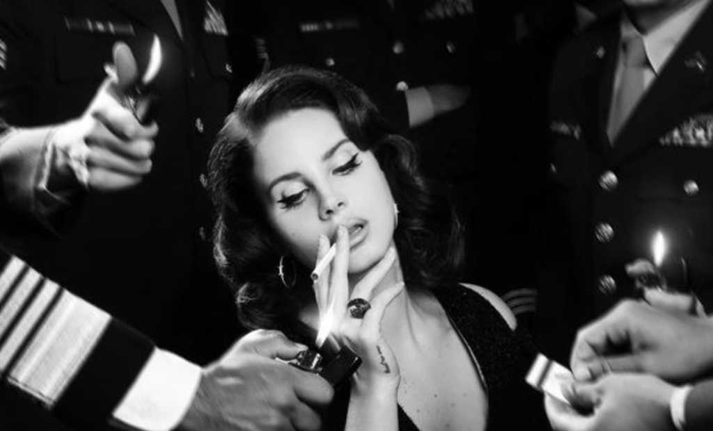

# My picks

## My favorite album

[figure not shown]

## My favorite song

[Ride (2012, Youtube link)](https://www.youtube.com/watch?v=nvb8wdBglpw)

## My favorite lyrics

> I hear the birds on the summer breeze, I drive fast  
> I am alone at midnight  
> Been tryin’ hard not to get into trouble, but I  
> I’ve got a war in my mind  
> So, I just ride  
> Just ride, I just ride, I just ride

# Import data

```r
#These are the packages I need for the analysis
library(ggplot2)
library(dplyr)
library(knitr)
library(readr)
data <- read_csv("Lana Del Rey.csv")
```

# Take a glance of the data frame

```r
# Slice 5 random records in the dataframe
data |> dplyr::slice_sample(n=5) |> knitr::kable(digits = 2)
```

| artist_name | track_name | track_number | album_name | album_release_year | album_release_date | valence | energy | danceability | loudness | tempo | speechiness | instrumentalness | liveness | key_name | mode_name | key_mode | duration_ms |
| --- | --- | --- | --- | --- | --- | --- | --- | --- | --- | --- | --- | --- | --- | --- | --- | --- | --- |
| Lana Del Rey | Blue Jeans - Remastered 2011 | 3 | Born To Die – Paradise Edition (Special Version) | 2012 | 2012-01-01 | 0.50 | 0.83 | 0.55 | -4.40 | 117.95 | 0.06 | 0.00 | 0.08 | D# | major | D# major | 209440 |
| Lana Del Rey | For Free | 11 | Chemtrails Over The Country Club | 2021 | 2021-03-19 | 0.20 | 0.10 | 0.50 | -13.38 | 114.04 | 0.03 | 0.00 | 0.07 | F | major | F major | 251818 |
| Lana Del Rey | The Other Woman | 11 | Ultraviolence (Deluxe) | 2014 | 2014-01-01 | 0.17 | 0.47 | 0.26 | -6.43 | 111.67 | 0.03 | 0.25 | 0.34 | G | minor | G minor | 181960 |
| Lana Del Rey | Lucky Ones | 15 | Born To Die – Paradise Edition (Special Version) | 2012 | 2012-01-01 | 0.32 | 0.42 | 0.32 | -7.19 | 134.44 | 0.03 | 0.00 | 0.15 | C | major | C major | 227306 |
| Lana Del Rey | Cruel World | 1 | Ultraviolence (Deluxe) | 2014 | 2014-01-01 | 0.18 | 0.51 | 0.33 | -6.37 | 122.16 | 0.03 | 0.00 | 0.12 | F | minor | F minor | 399083 |

# Data preparation

I am only interested to know more about my top 3 favorite Lana Del Rey albums. Thus, I decided to only select those three for my study. These include: “Born To Die - The Paradise Edition”, “Ultraviolence (Deluxe)” and “Honeymoon.”

```r
#Remove records with the same track names
data <- data |> distinct(track_name, .keep_all = TRUE)
data <- data |> filter(!grepl("pattern_to_exclude", track_name))
data$album_name <- as.character(data$album_name)
```

# Album analysis (valence and energy)

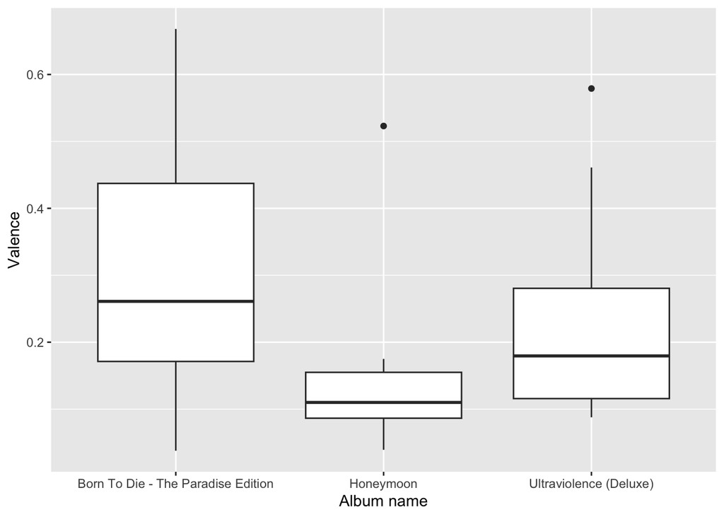

```r
# Change album_name from character to factor before plotting
data$album_name <- as.factor(data$album_name)

# Filter data for the specific albums you want
selected_albums <- c("Born To Die - The Paradise Edition", "Ultraviolence (Deluxe)", "Honeymoon")
filtered_data <- data[data$album_name %in% selected_albums, ]

# Plot a boxplot
library(ggplot2)
ggplot(filtered_data, aes(x = album_name, y = valence)) +
  geom_boxplot() +
  labs(x = "Album name", y = "Valence")
```

For valence level, the album Honeymoon has the lowest median. Was Lana Del Rey sad when writing songs for the album Honeymoon?

Let’s see if Honeymoon also has the lowest energy level.

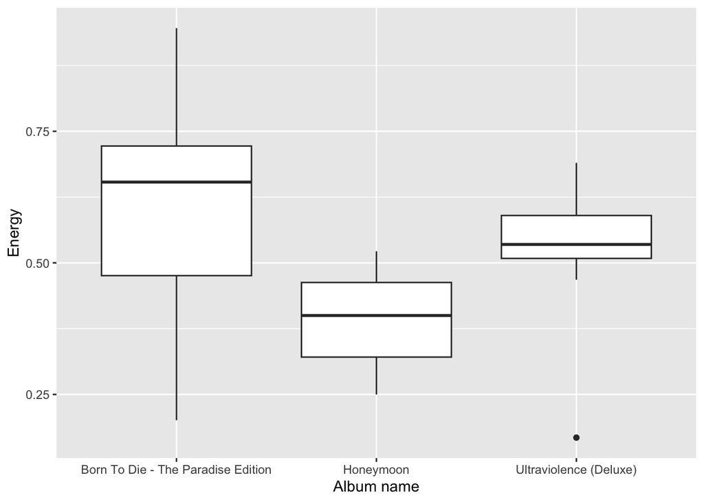

```r
# Change album_name from character to factor before plotting
data$album_name <- as.factor(data$album_name)

# Filter data for the specific albums you want
selected_albums <- c("Born To Die - The Paradise Edition", "Ultraviolence (Deluxe)", "Honeymoon")
filtered_data <- data[data$album_name %in% selected_albums, ]

# Plot a boxplot
library(ggplot2)
ggplot(filtered_data, aes(x = album_name, y = energy)) +
  geom_boxplot() +
  labs(x = "Album name", y = "Energy")
```

When looking at Lana Del Rey’s energy level in the album Honeymoon, it is also the lowest!

# Album analysis (density)

Now that we have analysed the energy and valence levels of my favorite Lana Del Rey albums, let’s see if they differ regarding the tempo density.

```r
# Print unique values in the "album_name" column to check the exact names
print(unique(data$album_name))
```

```
 [1] Born To Die - The Paradise Edition
 [2] Born To Die
 [3] Born To Die – Paradise Edition (Special Version)
 [4] Ultraviolence (Deluxe)
 [5] Honeymoon
 [6] Lust For Life
 [7] Norman Fucking Rockwell!
 [8] Blue Banisters
 [9] Chemtrails Over The Country Club
[10] Did you know that there's a tunnel under Ocean Blvd
10 Levels: Blue Banisters Born To Die ... Ultraviolence (Deluxe)
```

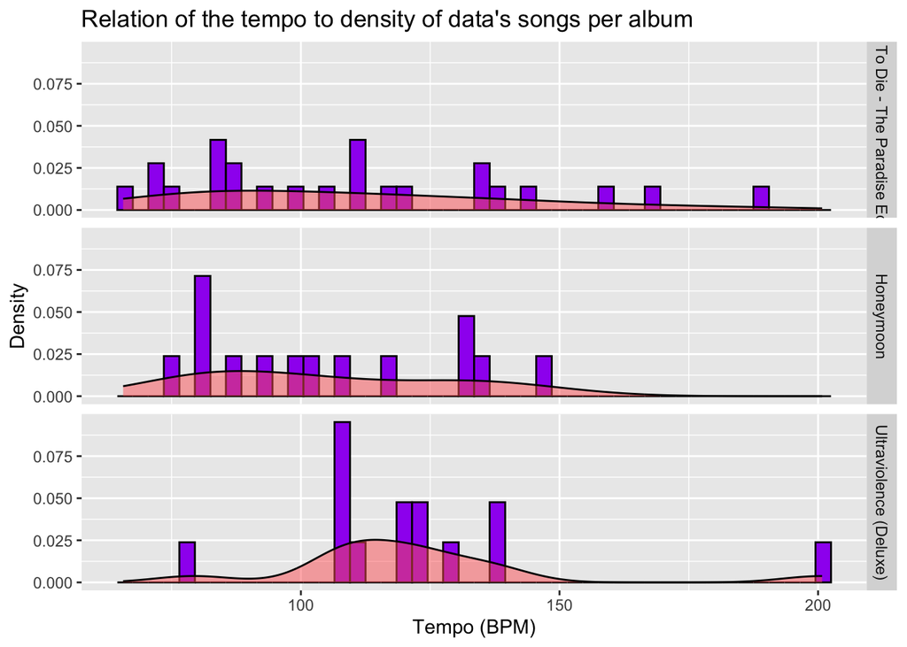

```r
# Filter data for the specific albums you want
selected_albums <- c("Born To Die - The Paradise Edition", "Ultraviolence (Deluxe)", "Honeymoon")
filtered_data <- data[data$album_name %in% selected_albums, ]

# Plot histogram and density for the selected albums
library(ggplot2)
ggplot(filtered_data, aes(x = tempo)) +
  geom_histogram(aes(y = ..density..), fill = "purple", color = "black", binwidth = 3) +
  geom_density(fill = "#FF6666", alpha = 0.5) +
  facet_grid(album_name ~ .) +
  labs(title = "Relation of the tempo to density of data's songs per album", x = "Tempo (BPM)", y = "Density")
```

These results did not come as a surprise to me. This is the case as the album “Born To Die - The Paradise Edition” is mostly known for its poetic and emotive qualities rather than the concentration of musical elements.

To have a deeper overview of Lana Del Rey’s music, let’s take a look at the songs with the least valence level from my favorite albums of Lana Del Rey.

```r
filtered_data |> slice_min(valence, n=3) |> dplyr::select(track_name, album_name, album_release_year, valence) |> knitr::kable(digits = 2)
```

| track_name | album_name | album_release_year | valence |
| --- | --- | --- | --- |
| Carmen | Born To Die - The Paradise Edition | 2012 | 0.04 |
| Swan Song | Honeymoon | 2015 | 0.04 |
| Art Deco | Honeymoon | 2015 | 0.06 |

Caremen and Swan Song score the same levels regarding valence levels.

Will the results be the same when taking into consideration energy levels?

```r
filtered_data |> slice_min(energy, n=3)|> dplyr::select(track_name,album_name, album_release_year, energy) |> knitr::kable(digits = 2)
```

| track_name | album_name | album_release_year | energy |
| --- | --- | --- | --- |
| Old Money | Ultraviolence (Deluxe) | 2014 | 0.17 |
| Yayo | Born To Die - The Paradise Edition | 2012 | 0.20 |
| Video Games | Born To Die - The Paradise Edition | 2012 | 0.25 |

Now, let’s explore the relationship between Loudness and Energy with regards to all songs from my top 3 Lana Del Rey albums.

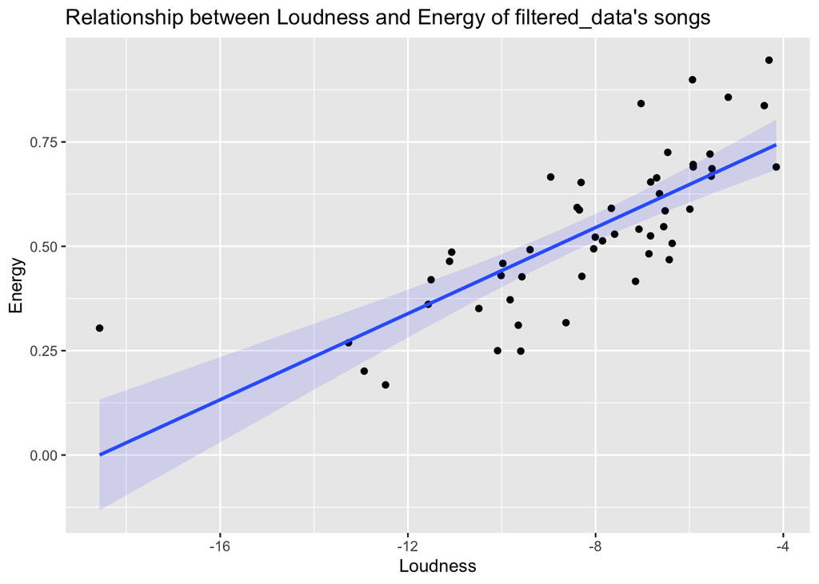

```r
ggplot(filtered_data, aes(x = loudness, y = energy,))+
  geom_point()+
  geom_smooth(method= "lm", alpha = 0.1, fill= "blue")+
  labs(title="Relationship between Loudness and Energy of filtered_data's songs", x="Loudness", y="Energy")
```

From these results, we can say that the louder the song gets, the more eneregetic it is.

Now, I am interested to check where my 3 favorite songs of my top 3 Lana Del Rey albums stand relatively to the rest of the songs from those three albums regarding energy and valence.

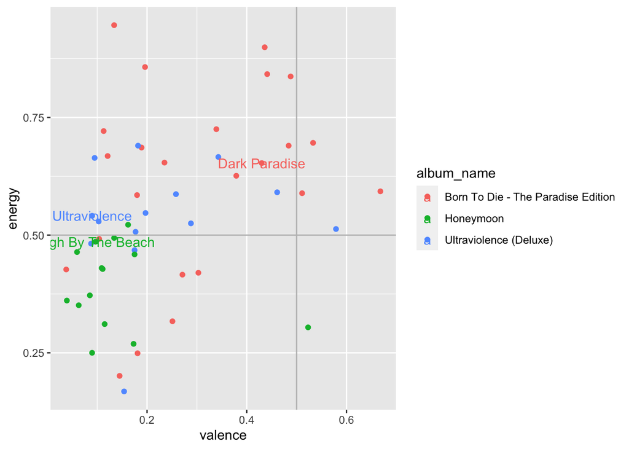

```r
subgroup <- data |> filter(track_name %in% c("Dark Paradise","Ultraviolence","High By The Beach"))
ggplot(filtered_data, aes(x = valence, y = energy, color = album_name))+
  geom_point()+
  geom_hline(yintercept = 0.5, color="grey")+
  geom_vline(xintercept = 0.5, color="grey")+
  geom_text(data=subgroup, aes(label=track_name))
```

We can see now that High By The Beach, for example is one of the highest energetic songs from the album it is from. Nevetheless, it remains a fairly calm song, like the rest of the album, as it has a score of 0.50 out of 1 in energy levels.

# Data analysis (Speechiness)

Lana Del Rey is one of my favorite artists because I find her songwriting evocative and distinct. My favorite album is “Born To Die - The Paradise Edition” for that precise reason. In this way, let’s observe if the level of speechiness is the highest for that album!

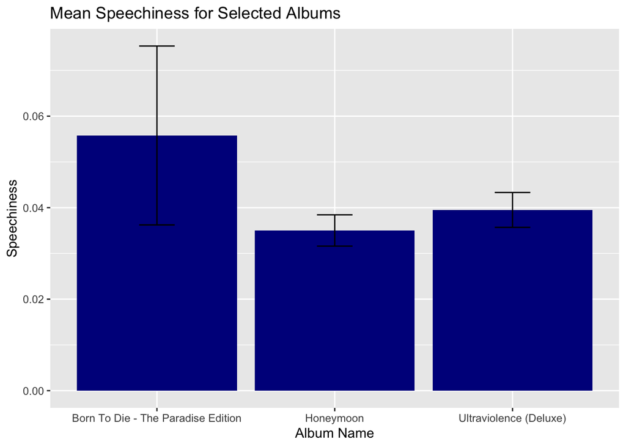

```r
# Assuming album_name is already a factor in your data
data$album_name <- as.factor(data$album_name)

# Filter data for the specific albums you want
selected_albums <- c("Born To Die - The Paradise Edition", "Ultraviolence (Deluxe)", "Honeymoon")
filtered_data <- data[data$album_name %in% selected_albums, ]

# Plot bar plot with error bars for mean speechiness
library(ggplot2)
ggplot(filtered_data, aes(x = album_name, y = speechiness)) +
  stat_summary(fun.y = mean, geom = "bar", position = "dodge", fill = "darkblue") +
  stat_summary(fun.data = mean_cl_normal, geom = "errorbar", position = "dodge", width = 0.2, color = "black") +
  labs(title = "Mean Speechiness for Selected Albums", x = "Album Name", y = "Speechiness")
```

“Born To Die - The Paradise Edition” is indeed the album with the highest speechiness level.

All in all, from the albums I analysed, my favorite album, “Born To Die - The Paradise Edition” has the highest valence, energy, speechiness levels and the lowest density level.